# Delineating the neighborhoods of Magude

A programmatic approach

Joe Brew, Bea Galatas, Humberto Munguambe, Amone Felimone, Pedro Aide

2017-04-04

```r
knitr::opts_chunk$set(comment = NA,
               echo = TRUE,
               warning = FALSE,
               message = FALSE,
               error = TRUE,
               cache = FALSE)
```

## Overview

This document provides a simple overview of an approach for creating neighborhood delineations using point data. Though the specific application here is for the MALTEM project in the district of Magude, the approach is generalizable to other areas. This document provides both explanation as well as code.

bairro

## Workspace preparation

First, we prepare our workspace by attaching several libraries.

```r
library(dplyr)
library(sp)
library(cism)
library(rgeos)
library(geosphere)
library(readxl)
```

We then load up our point data (the houses of the census of Magude). In the below, we use the `cism` package to quickly access the MALTEM database.

www.github.com/joebrew/cism

```r
if('2016-12-07_HOUSEHOLD.RData' %in% dir('data')){
  load('data/2016-12-07_HOUSEHOLD.RData')
} else {
  HOUSEHOLD <- get_data(dbname = 'MALTEM',
                tab = 'HOUSEHOLD')
  save(HOUSEHOLD,
       file = 'data/2016-12-07_HOUSEHOLD.RData')
}
```

Next, we read in the dictionary of neighborhood numbers/names prepared by Humberto.

```r
# Read in the bairros names
dict <- read_excel('public_data/lista total de agregados por bairro.xlsx',
                   skip = 1)
```

We then carry out some straightforward “cleaning”.

```r
# Get a bairro number
dict$bairro_number <-
  as.numeric(unlist(lapply(dict$`Cod do Bairro`,
                           function(x){
                             substr(x, 3, 4)
                           })))

# Clean up names and narrow
dict <- dict %>%
  dplyr::select(bairro_number,
                `posto Administrativo`,
                Bairros) %>%
  rename(posto_administrativo = `posto Administrativo`,
         bairro_name = Bairros)

# Get shorter name
df <- HOUSEHOLD

# Specify coordinates
df$lng <- df$HOUSEHOLD_HEAD_GPS_LNG
df$lat <- df$HOUSEHOLD_HEAD_GPS_LAT

# Get neighborhood number
df$bairro_number <-
  unlist(lapply(df$HOUSEHOLD_HEAD_AGREG_NUM,
                function(x){
                  substr(x, 3,4)
                }))
df$bairro_number <- as.numeric(as.character(df$bairro_number))

# Narrow data
df <- df %>%
  dplyr::select(bairro_number,
                lng,
                lat) %>%
  mutate(x = lng,
         y = lat) %>%
  filter(!is.na(lng),
         !is.na(lat))
```

## Spatial operations

Once we have our point data read in, we make a spatial object.

```r
# Make spatial
coordinates(df) <- ~x+y
proj4string(df) <- proj4string(mag2)
```

Since some points are likely incorrect (and this can throw off our estimates by creating artificially small or large neighborhoods), we keep only those points which are closest to the others which are supposedly in the same neighborhood.

```r
df@data$id <- 1:nrow(df)
df@data$suspect <- FALSE

# Get unique bairros
bairros <- data_frame(bairro_number = sort(unique(df$bairro_number)))

# Remove form our household data, those points which
# are suspiciously far from others
for (i in 1:nrow(bairros)){
  # Get info just for this bairro
  this_bairro <- bairros$bairro_number[i]
  sub_df <- df[df@data$bairro_number == this_bairro,]
  # Get distances between points
  distances <- geosphere::distm(sub_df, fun = distVincentySphere)
  median_distances <- apply(distances, 1, function(x){quantile(x, 0.75, na.rm = TRUE)})
  # Keep only the closest 50 percent
  close_cluster <- sub_df[which(median_distances <= median(median_distances, na.rm = TRUE)),]
  # Flag those which are suspicious
  far_cluster <- sub_df[which(median_distances > median(median_distances, na.rm = TRUE)),]
  df$suspect[df$id %in% far_cluster$id] <- TRUE
}

# Remove those which are suspicious
df <- df[!df@data$suspect,]
```

Having now filtered out the 50% of points deemed to be most “suspicious”, we get the centroid of each neighborhood.

```r
# Get centroids
bairros$x <- bairros$y <- NA
for (i in 1:nrow(bairros)){
  # Get info just for this bairro
  this_bairro <- bairros$bairro_number[i]
  sub_df <- df[df@data$bairro_number == this_bairro,]
  bairros$x[i] <- mean(sub_df$lng, na.rm = TRUE)
  bairros$y[i] <- mean(sub_df$lat, na.rm = TRUE)
}
```

### Convex hulls, delaunay tesselation, and voronoi polygons

A neighborhood, per our methodology, is the convex hull of all its constituents, as well as any point (theoretical or observed) which is closer to that convex hull than to any other convex hull. In order to calculate these borders, we use delaunay triangulation to establish cut-offs, before forming voronoi polygons as our neighborhoods.

outer border

```r
# Create convex hulls
ch <- list()
for (i in 1:nrow(bairros)){
  this_bairro <- bairros$bairro_number[i]
  sub_df <- df[df@data$bairro_number == this_bairro,]
  x <- rgeos::gConvexHull(sub_df)
  ch[[i]] <- x
}

# Create delaunay triangulation / voronoi tiles for entire surface
voronoi <- function(shp = df){

  shp@data <- data.frame(shp@data)

  # Fix row names
  row.names(shp) <- 1:nrow(shp)

  # Remove any identical ones
  shp <- shp[!duplicated(shp$lng,
                                                     shp$lat),]

  # Helper function to create coronoi polygons (tesselation, not delaunay triangles)
  # http://carsonfarmer.com/2009/09/voronoi-polygons-with-r/
  voronoipolygons = function(layer) {
    require(deldir)
    crds = layer@coords
    z = deldir(crds[,1], crds[,2])
    w = tile.list(z)
    polys = vector(mode='list', length=length(w))
    require(sp)
    for (i in seq(along=polys)) {
      pcrds = cbind(w[[i]]$x, w[[i]]$y)
      pcrds = rbind(pcrds, pcrds[1,])
      polys[[i]] = Polygons(list(Polygon(pcrds)), ID=as.character(i))
    }
    SP = SpatialPolygons(polys)
    voronoi = SpatialPolygonsDataFrame(SP, data=data.frame(x=crds[,1],
                                                           y=crds[,2], row.names=sapply(slot(SP, 'polygons'),
                                                                                        function(x) slot(x, 'ID'))))
  }
  # http://gis.stackexchange.com/questions/180682/merge-a-list-of-spatial-polygon-objects-in-r
  appendSpatialPolygons <- function(x) {
    ## loop over list of polygons
    for (i in 2:length(x)) {
      # create initial output polygon
      if (i == 2) {
        out <- maptools::spRbind(x[[i-1]], x[[i]])
        # append all following polygons to output polygon
      } else {
        out <- maptools::spRbind(out, x[[i]])
      }
    }
    return(out)
  }

  tile_polys <- voronoipolygons(shp)
  # Add the bairro numbers
  tile_polys@data$bairro_number <- the_bairros <- shp$bairro_number
  cols <- rainbow(as.numeric(factor(tile_polys@data$bairro_number)))

  # Disolve borders
  x = gUnaryUnion(tile_polys, id = tile_polys$bairro_number)

  jdata = SpatialPolygonsDataFrame(Sr=x,
                                   data=data.frame(bairro_number = as.numeric(as.character(names(x)))),FALSE)

  return(jdata)
}

# Get voronoi tesselations
dfv <- voronoi(shp = df)
```

## Results

Having carried out the polygon delineation, we plot the results.

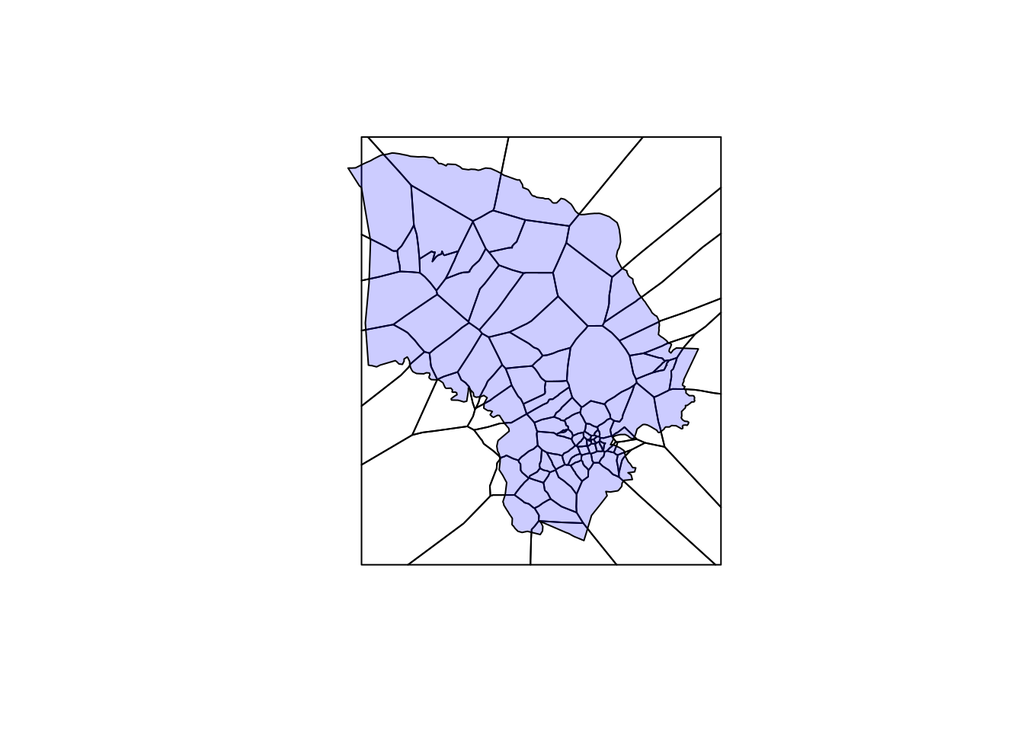

```r
# Plot in current state
plot(dfv)
plot(mag2, add = T, col = adjustcolor('blue', alpha.f = 0.2))
```

In the above, our methodology works well within Magude; but at borders, our neighborhoods expand infinitely outwards. In order to account for this, we can trim our polygons to keep only those segments which fall into Magude.

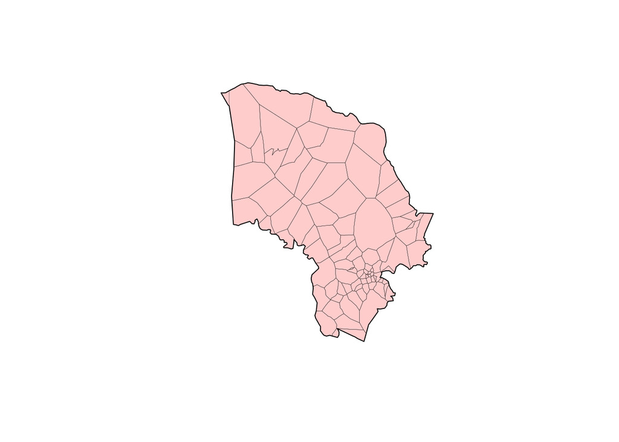

```r
# Narrow down so as to only keep those areas which are IN Magude
proj4string(dfv) <- proj4string(mag2)
out <- gIntersection(dfv, mag2, byid=TRUE)

# Join with data
row.names(out) <- as.character(1:length(out))
out <- SpatialPolygonsDataFrame(out, data.frame(bairros), match.ID = TRUE)

# Plot again
plot(mag2, col = adjustcolor('red', alpha.f = 0.2))
plot(out, add = T, lwd = 0.2)
```

The below interactive map allows for manual examination of neighborhoods.

```r
# Join in info on bairros
dict$full_name <- paste0(dict$posto_administrativo,
                         ': ',
                         dict$bairro_name)
out@data <- left_join(out@data,
                      dict,
                      by = 'bairro_number')
bairros <- left_join(bairros,
                     dict,
                     by = 'bairro_number')


# Plot leaflet
library(leaflet)
leaflet() %>%
  addProviderTiles(provider = 'Stamen.Toner') %>%
  addPolygons(data = out,
              color = 'green',
              popup = out@data$bairro_name)
```

[interactive chart not shown]

## Data products

Having finished our implementation of neighborhood delineation, we write a shapefile, so that others can use the neighborhoods, regardless of their GIS software.

```r
library(rgdal)
writeOGR(obj=out,
         dsn="magude_bairros",
         layer = 'magude_bairros',
         driver="ESRI Shapefile")
```

The standard shapefile components now exist in our `magude_bairros` directory:

```r
dir('magude_bairros/')
```

```
[1] "magude_bairros.dbf" "magude_bairros.prj" "magude_bairros.shp"
[4] "magude_bairros.shx"
```

They are available for download at www.github.com/joebrew/magude_bairros/magude_bairros. Once human inspection confirms the validity of this approach, I will make the `magude_bairros` object part of the CISM package.

Humberto and Bea?